# A Common Technology Profile

- Show All Code
- Hide All Code
- View Source

Is a single ‘standard capability radar’ countries evolve toward defensible — and where do negative (avoid) weights belong? A follow-on to the SHAP replication.

Author

Net Zero Industrial Policy Lab (NZIPL) · Johns Hopkins SAIS

Published

July 7, 2026

```r
library(readr); library(dplyr); library(tidyr); library(stringr); library(forcats)
library(ggplot2); library(patchwork); library(knitr); library(showtext); library(tibble)
font_add_google("Archivo", "Archivo"); showtext_auto(); showtext_opts(dpi = 200)

NZ_DARK <- "#073309"; NZ_GREEN <- "#3cb54a"; NZ_TEAL <- "#0d9488"
theme_nr <- function(...) theme_minimal(base_family = "Archivo", base_size = 12) +
  theme(plot.title = element_text(size = 14, face = "bold", colour = NZ_DARK),
        plot.subtitle = element_text(size = 11, colour = "#475569"),
        panel.grid.minor = element_blank(), ...)
theme_set(theme_nr())
CAT_COL <- c(Chemicals="#2563eb", Electronics="#7c3aed", Metals="#ef4444",
             Machinery="#10b981", "Industrial Materials"="#f59e0b", Other="#6b7280", "Non-HS"="#94a3b8")
CATS <- c("Chemicals","Electronics","Industrial Materials","Machinery","Metals")
CATS_SHORT <- c(Chemicals="Chem", Electronics="Elec", "Industrial Materials"="Ind.\nMat.",
                Machinery="Mach", Metals="Met")
TECHS <- c("Solar","Wind","Batteries","EVs","Nuclear","Geothermal",
           "Heat Pumps","Electrolyzers","Transmission","Magnets","Biofuel")

ml <- here::here("analysis","ml")
feat  <- read_csv(file.path(ml,"shap_replication_features.csv"), show_col_types = FALSE) |>
  mutate(retained = as.logical(retained))
catt  <- read_csv(file.path(ml,"shap_replication_by_category.csv"), show_col_types = FALSE)
bycl  <- read_csv(file.path(ml,"shap_replication_by_class.csv"), show_col_types = FALSE) |>
  mutate(retained = as.logical(retained))
crank <- read_csv(file.path(ml,"shap_replication_country_rank.csv"), show_col_types = FALSE)
ex    <- read_csv(file.path(ml,"shap_replication_cy_examples.csv"), show_col_types = FALSE)
disp  <- read_csv(file.path(ml,"shap_replication_cy_dispersion.csv"), show_col_types = FALSE)
gd    <- read_csv(here::here("data","green_dict","green_dictionary.csv"), show_col_types = FALSE) |>
  distinct(code, name) |> mutate(code = as.character(code))
hs_name <- function(hs) { nm <- gd$name[match(as.character(hs), gd$code)]; ifelse(is.na(nm), "", nm) }
```

**Where this sits.** The companion `ml_replication.qmd` reproduced the shipped SHAP need-axis from source and showed it discards three things — **magnitude, sign, and the country dimension**. That note was *diagnostic*. This one is *constructive*: the co-directors want a single **standard capability radar per technology — the profile a country’s industrial policy steers toward.** That is a legitimate object, but only if (a) a common profile actually *exists* across countries, and (b) we know where “**don’t specialise here**” (negative) weights belong. Both questions are answered here from the same regenerated SHAP (`analysis/ml/`, produced by `scripts/ml/regen_shap.py` + `scripts/ml/target_profile_prep.py`), with the RCA>1 “competitive” class reconstructed per country-year from the CICE trade files — no model re-fit.

# 1 Two layers: the target and the gap

The audit and the co-directors are not actually in conflict — they are describing **two different objects** that the shipped pipeline collapses into one:

|  | **Target profile** | **Country gap** |
| --- | --- | --- |
| Question | *What does technology X require?* | *How far is country C from it, and in which direction?* |
| Varies by country? | **No** — one profile per tech | **Yes** — one per country |
| Needs sign? | Only to say what’s on- vs off-path | **Yes** — surplus vs deficit, build vs avoid |
| Natural unit | cluster shares of a canonical fingerprint | that country’s own SHAP row vs the target |

`ml_replication` faulted the shipped radar for being **country-invariant and unsigned**. But country-invariance is a *feature* of the target layer, not a bug — a “standard profile countries evolve toward” is by definition the same for everyone. The critique bites on the **gap** layer, where sign and the country dimension genuinely live. So the constructive question splits cleanly:

1. **Is the target layer well-defined?** Do countries agree on *what the technology needs* strongly enough that a single profile is meaningful? (§2–§3)
2. **How does sign enter?** Where is “don’t specialise here”, and does the shipped `|SHAP|` throw away something the target radar needs? (§4)
3. **What does the corrected target radar look like, and how is it built?** (§5–§6)

# 2 Re-reading EDA 4 — what the dispersion numbers actually said

`ml_replication`’s EDA 4 reported four alarming numbers about how the pooled `mean|SHAP|` hides country-year variation. They are easy to over-read, so here is one feature, concretely. Take Solar’s **HS 830249 (mounting equipment)** — a retained radar feature — across all 3410 country-years:

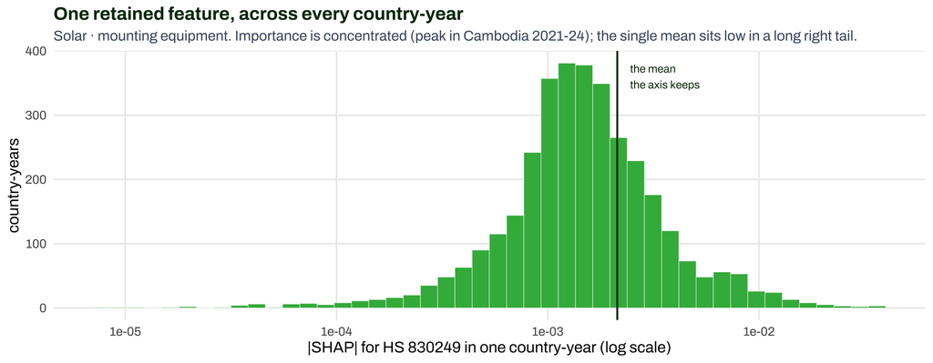

```r
w <- ex |> filter(tech=="Solar", feature=="s_830249")
mw <- mean(w$abs_shap)
stats <- tibble(
  Statistic = c("CV (spread ÷ mean)", "max ÷ mean", "% of country-years below ½ the mean",
                "top-2% country-years' share of total"),
  Value = c(sprintf("%.2f", sd(w$abs_shap)/mw),
            sprintf("%.0f×", max(w$abs_shap)/mw),
            sprintf("%.0f%%", mean(w$abs_shap < mw/2)*100),
            sprintf("%.0f%%", sum(sort(w$abs_shap, decreasing=TRUE)[1:ceiling(.02*nrow(w))])/sum(w$abs_shap)*100)),
  `Plain meaning` = c("the importance varies more across countries than its own average",
                      "for one country-year it matters ~17× more than the reported mean",
                      "for a third of countries it is nearly inert",
                      "a handful of countries carry most of the total"))
ggplot(w, aes(abs_shap + 1e-6)) +
  geom_histogram(bins = 46, fill = NZ_GREEN, colour = "white", linewidth = .15) +
  geom_vline(xintercept = mw, colour = NZ_DARK, linewidth = .7) +
  annotate("text", x = mw*1.15, y = Inf, vjust = 1.6, hjust = 0, family = "Archivo", size = 3,
           colour = NZ_DARK, label = "the mean\nthe axis keeps") +
  scale_x_log10() +
  labs(x = "|SHAP| for HS 830249 in one country-year (log scale)", y = "country-years",
       title = "One retained feature, across every country-year",
       subtitle = paste0("Solar · mounting equipment. Importance is concentrated (peak in Cambodia 2021-24); ",
                         "the single mean sits low in a long right tail."))
```

```r
kable(stats, caption = "The four EDA-4 statistics for one feature, in plain language. Every one of them is a statement about how MAGNITUDE varies across countries.")
```

The four EDA-4 statistics for one feature, in plain language. Every one of them is a statement about how MAGNITUDE varies across countries.

[output not shown]

**Reading the histogram.** The horizontal axis (log scale) is this feature’s `|SHAP|` in a *single* country-year; each bar counts how many country-years fall in that importance band; the vertical line is the one average the pipeline keeps. The mean sits low on a long right tail — dragged down by the many countries for which mounting-equipment capability barely moves the prediction, and pulled up only by the handful (here, Cambodia 2021–24) for which it is decisive. So the single reported number describes almost no individual country well. The table restates that in four ways.

**The point that was missing.** Every one of these numbers measures how the *magnitude* of a feature’s importance varies across countries. That matters enormously for a **country gap** (“how much does mounting-equipment capability matter *for Cambodia specifically*”) — but it does **not**, on its own, sink a **target profile**. A standard profile does not require the magnitude to be equal across countries; it only requires the **shape** — which capabilities rank high relative to each other — to be shared. EDA 4 measured scale dispersion and left the shape question open. §3 asks it directly.

# 3 Does a common profile exist? Shape, not scale

For each technology, take **each country’s own importance vector** (its mean `|SHAP|` per feature over its years) and rank-correlate it against the pooled profile. If countries agree on the *ranking* of capabilities — even while differing wildly in magnitude — then a single target profile is a faithful summary of a shared shape.

[figure not shown]

```r
cr <- crank |> filter(!is.na(spearman_retained)) |> mutate(tech = factor(tech, TECHS))
med <- cr |> group_by(tech) |> summarise(m = median(spearman_retained), .groups="drop")
p1 <- ggplot(cr, aes(x = fct_rev(tech), y = spearman_retained)) +
  geom_hline(yintercept = c(0, .5, 1), linetype = "22", colour = "grey85") +
  geom_violin(fill = NZ_GREEN, alpha = .25, colour = NA, scale = "width") +
  geom_boxplot(width = .18, outlier.size = .5, fill = "white", colour = NZ_DARK, linewidth = .4) +
  coord_flip(ylim = c(0, 1)) +
  labs(x = NULL, y = "each country's rank-agreement with the pooled profile (Spearman ρ)",
       title = "Countries agree on the SHAPE of what each tech needs",
       subtitle = paste0("Per-country importance vectors vs the pooled profile, retained radar features. ",
                         "Median ρ = ", round(median(cr$spearman_retained),2), " overall."))
p2 <- ggplot(cr, aes(frac_competitive, spearman_retained)) +
  geom_point(alpha = .25, size = 1, colour = NZ_TEAL) +
  geom_smooth(method = "lm", se = FALSE, colour = NZ_DARK, linewidth = .7) +
  labs(x = "share of years the country is RCA-competitive", y = "rank-agreement (ρ)",
       title = "Have-nots share the starting line; winners specialise",
       subtitle = "Non-competitive countries hug the common profile; competitive ones deviate into niches.")
p1 | p2
```

**Reading the two panels.** Let us take them one at a time. The left panel has one row per technology; each violin-and-box summarises, across that technology’s many countries, a single score per country — how closely that country *ranks* the capabilities the same way the pooled profile does (Spearman’s ρ, where 1 means an identical ordering and 0 means no relationship). The boxes cluster high and tight, around 0.8–0.95, so the reassuring message is that countries broadly agree on *which* capabilities a technology leans on, even though EDA 4 showed they differ enormously in *how much*. The right panel then asks a gentler follow-up: does that agreement depend on how advanced a country is? Each dot is one country; the horizontal axis is the share of years it was competitive (`RCA>1`), the vertical axis its rank-agreement. The line slopes *down* — at first glance surprising — because a country that is short on nearly everything trivially traces the common shape, while a country that has actually become competitive has bent its own profile toward a specialisation. So the shared profile is best pictured as the on-ramp everyone starts on, not a description of where the winners end up.

```r
crank |> filter(!is.na(spearman_retained)) |> mutate(tech = factor(tech, TECHS)) |>
  group_by(tech) |>
  summarise(`N countries`=n(), `median ρ`=round(median(spearman_retained),2),
            `10th pct ρ`=round(quantile(spearman_retained,.1),2),
            `% above 0.7`=round(mean(spearman_retained>.7)*100,0), .groups="drop") |>
  arrange(tech) |>
  kable(caption = "Per-tech rank agreement between each country's importance vector and the pooled profile. Even the 10th-percentile country is well above chance; a common profile is a defensible summary of a shared shape.")
```

Per-tech rank agreement between each country’s importance vector and the pooled profile. Even the 10th-percentile country is well above chance; a common profile is a defensible summary of a shared shape.

| tech | N countries | median ρ | 10th pct ρ | % above 0.7 |
| --- | --- | --- | --- | --- |
| Solar | 155 | 0.85 | 0.70 | 90 |
| Wind | 155 | 0.88 | 0.77 | 95 |
| Batteries | 155 | 0.89 | 0.78 | 98 |
| EVs | 158 | 0.94 | 0.82 | 99 |
| Nuclear | 155 | 0.93 | 0.74 | 92 |
| Geothermal | 155 | 0.90 | 0.80 | 98 |
| Heat Pumps | 155 | 0.93 | 0.75 | 94 |
| Electrolyzers | 155 | 0.86 | 0.72 | 94 |
| Transmission | 155 | 0.88 | 0.57 | 81 |
| Magnets | 155 | 0.90 | 0.71 | 90 |
| Biofuel | 155 | 0.79 | 0.54 | 69 |

**Read.** Median rank-agreement is **0.88** and never below ~0.8 at the tech level — countries overwhelmingly agree on *which* capabilities a technology leans on, differing mainly in *how much* (the EDA-4 scale story). So the co-directors’ object is justified: **a single target profile is a real, shared shape.** The one nuance (right panel): countries that are *not yet* competitive agree with the profile **most** (they are uniformly “short” everywhere), while *competitive* producers deviate — each has specialised into a niche. The common profile is therefore best read as the **aspirational path a not-yet-competitive country climbs**, with successful producers branching into specialisations once on it.

# 4 Where negative weights belong

The intuition behind wanting sign is right: a target radar should distinguish “**build this**” from “**don’t specialise here**”, and the shipped `|SHAP|` cannot. But the naive fix — sign the *pooled* mean SHAP — is **wrong**, and the replication data shows exactly why.

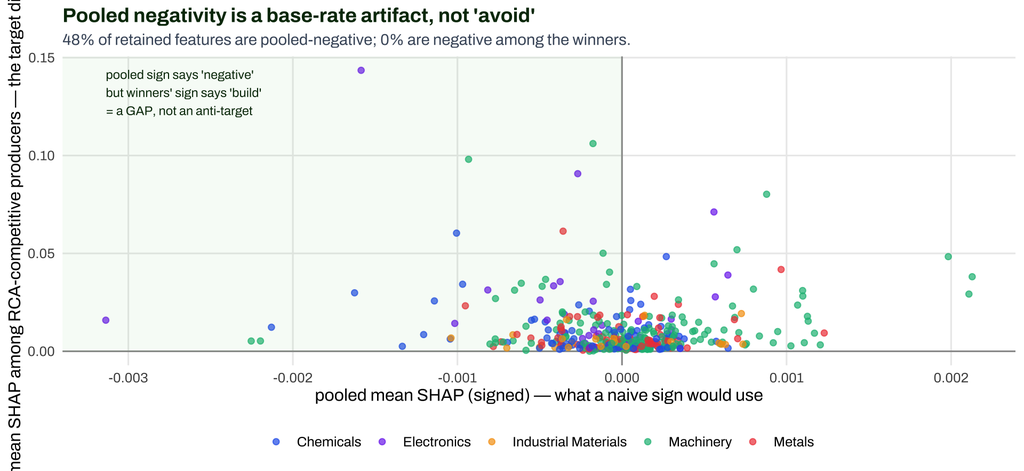

```r
rr <- bycl |> filter(retained, category %in% CATS)
share_neg_pooled <- round(mean(rr$mean_shap_signed < 0)*100, 0)
share_neg_comp   <- round(mean(rr$mean_shap_comp < 0)*100, 0)
ggplot(rr, aes(mean_shap_signed, mean_shap_comp, colour = category)) +
  geom_hline(yintercept = 0, colour = "grey60") + geom_vline(xintercept = 0, colour = "grey60") +
  geom_point(alpha = .7, size = 1.7) +
  scale_colour_manual(values = CAT_COL, name = NULL) +
  annotate("rect", xmin = -Inf, xmax = 0, ymin = 0, ymax = Inf, alpha = .05, fill = NZ_GREEN) +
  annotate("text", x = min(rr$mean_shap_signed), y = max(rr$mean_shap_comp), hjust = 0, vjust = 1,
           family = "Archivo", size = 3.1, colour = NZ_DARK,
           label = "pooled sign says 'negative'\nbut winners' sign says 'build'\n= a GAP, not an anti-target") +
  labs(x = "pooled mean SHAP (signed) — what a naive sign would use",
       y = "mean SHAP among RCA-competitive producers — the target direction",
       title = "Pooled negativity is a base-rate artifact, not 'avoid'",
       subtitle = paste0(share_neg_pooled, "% of retained features are pooled-negative; ",
                         share_neg_comp, "% are negative among the winners.")) +
  theme(legend.position = "bottom")
```

**Reading the plot.** Each dot is one retained radar feature. Its horizontal position is the *pooled* mean signed SHAP — the number you would get by naively adding the sign back to the shipped axis, averaging over every country. Its vertical position is the mean SHAP among only the countries that are actually competitive (`RCA>1`) — the direction that matters if we want to describe a *winning* profile. The shaded band in the top-left is the crux: features that look **negative** when pooled over everyone but sit **positive** among the winners. A feature there is emphatically not something to avoid — competitive producers plainly benefit from it; it merely reads negative overall because most countries have not built it yet. That is the signature of a *gap*, not an anti-target — and it is why signing the pooled mean would mislead.

Because `RCA>1` is rare (~5% base rate), the large non-competitive majority reads as “not enough of everything” — so **48% of retained features carry a net-negative *pooled* SHAP**. That is the deficit of the have-nots, i.e. the **gap**, not a signal that the capability is bad to hold. Split the sign by the target class and the artifact disappears:

```r
allf <- bycl |> filter(category %in% CATS)
tibble(
  Group = c("All radar features", "Retained radar features"),
  `N` = c(nrow(allf), nrow(rr)),
  `% pooled-SHAP negative` = c(round(mean(allf$mean_shap_signed<0)*100,0), round(mean(rr$mean_shap_signed<0)*100,0)),
  `% negative among WINNERS` = c(round(mean(allf$mean_shap_comp<0)*100,0), round(mean(rr$mean_shap_comp<0)*100,0)),
  `% where winners < non-winners (disc<0)` = c(round(mean(allf$disc<0)*100,0), round(mean(rr$disc<0)*100,0))
) |> kable(caption = "Sign under two readings. Among competitive producers, essentially no retained feature points 'away' — and none is systematically lower among winners than non-winners. The pooled negativity was base rate.")
```

Sign under two readings. Among competitive producers, essentially no retained feature points ‘away’ — and none is systematically lower among winners than non-winners. The pooled negativity was base rate.

| Group | N | % pooled-SHAP negative | % negative among WINNERS | % where winners < non-winners (disc<0) |
| --- | --- | --- | --- | --- |
| All radar features | 830 | 51 | 0 | 0 |
| Retained radar features | 390 | 48 | 0 | 0 |

Among the **390** retained radar features, **0** are negative among competitive producers, and **0** are lower among winners than non-winners. In other words, for these 11 technologies there is **no meaningful “don’t specialise here” among the capabilities that reach the radar** — the winning recipes are uniformly additive. Genuine anti-targets do exist, but they are rare and sit *below* the selection bar:

```r
avoid <- bycl |> filter(category %in% CATS, mean_shap_comp < 0) |>
  arrange(mean_shap_comp) |>
  transmute(Tech = tech, HS = str_remove(feature, "^n?s_"),
            Product = hs_name(str_remove(feature, "^n?s_")), Cluster = category,
            `SHAP among winners` = round(mean_shap_comp, 5),
            Retained = ifelse(retained, "yes (on radar)", "no (below cut)"))
if (nrow(avoid) == 0) {
  cat("_No feature — retained or not — has a negative SHAP among competitive producers._")
} else kable(avoid, caption = "The only genuine 'avoid' candidates across all 11 techs: features that push competitive producers' predicted competitiveness DOWN. All sit below the selection cut, so none reaches the shipped radar.")
```

The only genuine ‘avoid’ candidates across all 11 techs: features that push competitive producers’ predicted competitiveness DOWN. All sit below the selection cut, so none reaches the shipped radar.

| Tech | HS | Product | Cluster | SHAP among winners | Retained |
| --- | --- | --- | --- | --- | --- |
| EVs | nev_850151 |  | Electronics | -0.00021 | no (below cut) |
| EVs | nev_720410 |  | Metals | -0.00002 | no (below cut) |

**Takeaway on sign.** Sign belongs in the model, but its job is **directional confirmation**, not carving negative wedges out of the radar. Building the target from the **competitive-class signed SHAP** gives an axis that *is* signed (so it can flag an anti-target if one appears) and *is* magnitude-preserving — and it happens to be all-positive here. The place negative numbers do real work is the **gap layer**: a specific country with a *surplus* in a cluster it should be de-emphasising. That is a country-level reading, not a property of the tech’s profile.